# Before we jump into predictive modeling, let's first understand the data using groupby and visualization.

```python
# Importing libraries
import pandas as pd
import matplotlib.pyplot as plt
```

```python
# Load your dataset (original file remains unchanged)
Top_50_US_Merged_Data = pd.read_csv('Top_50_US_Merged_2024_10_29_to_2024_11_26.csv')
Top_50_Mexico_Merged_Data = pd.read_csv('Top_50_Mexico_Merged_2024_10_29_to_2024_11_26.csv')
```

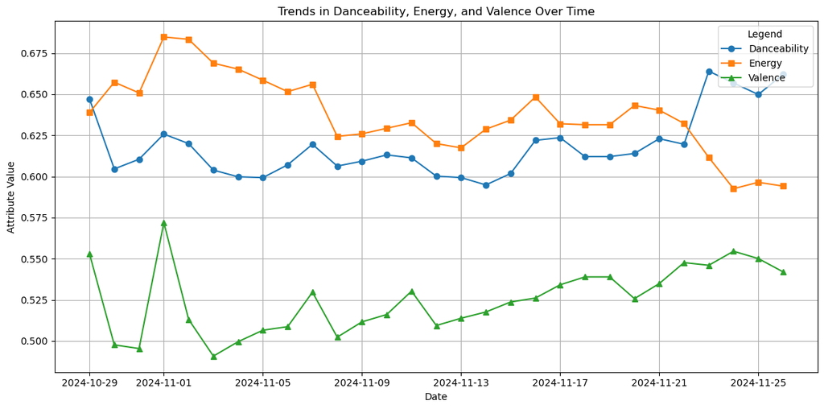

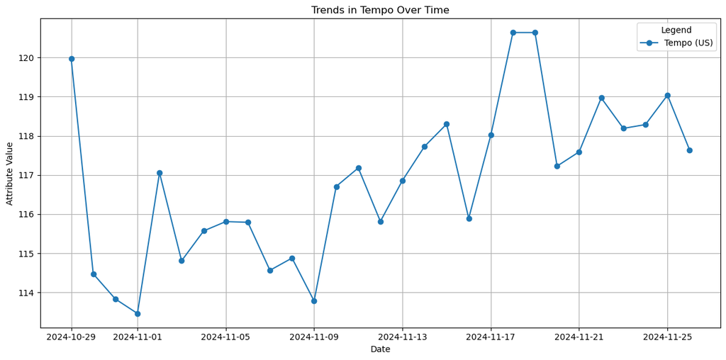

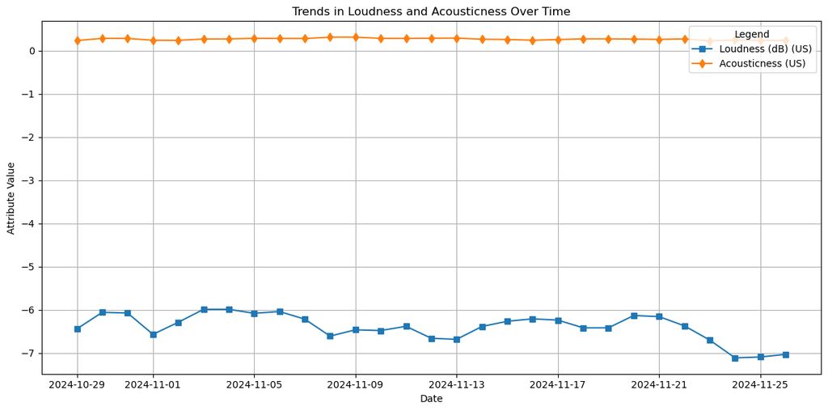

```python
# Convert ISO_Date to datetime
Top_50_US_Merged_Data['ISO_Date'] = pd.to_datetime(Top_50_US_Merged_Data['ISO_Date'])

# # Identify non-numeric columns
# non_numeric_columns = Top_50_US_Merged_Data.select_dtypes(exclude=['number']).columns
# print("Non-numeric columns:", non_numeric_columns)

# Group by date and calculate mean values for numerical attributes
numeric_columns = Top_50_US_Merged_Data.select_dtypes(include=['number']).columns
grouped_data = Top_50_US_Merged_Data.groupby('ISO_Date')[numeric_columns].mean()

# Plot Danceability, Energy, and Valence
plt.figure(figsize=(12, 6))
plt.plot(grouped_data.index, grouped_data['Danceability'], marker='o', label='Danceability', linestyle='-')
plt.plot(grouped_data.index, grouped_data['Energy'], marker='s', label='Energy', linestyle='-')
plt.plot(grouped_data.index, grouped_data['Valence'], marker='^', label='Valence', linestyle='-')
plt.title('Trends in Danceability, Energy, and Valence Over Time')
plt.xlabel('Date')
plt.ylabel('Attribute Value')
plt.legend(loc='upper right', title="Legend")
plt.grid()
plt.tight_layout()
plt.show()

# Plot Tempo
plt.figure(figsize=(12, 6))
plt.plot(grouped_data.index, grouped_data['Tempo'], marker='o', label='Tempo (US)', linestyle='-')
plt.title('Trends in Tempo Over Time')
plt.xlabel('Date')
plt.ylabel('Attribute Value')
plt.legend(loc='upper right', title="Legend")
plt.grid()
plt.tight_layout()
plt.show()

# Plot Loudness and Acousticness
plt.figure(figsize=(12, 6))
plt.plot(grouped_data.index, grouped_data['Loudness (dB)'], marker='s', label='Loudness (dB) (US)', linestyle='-')
plt.plot(grouped_data.index, grouped_data['Acousticness'], marker='d', label='Acousticness (US)', linestyle='-')
plt.title('Trends in Loudness and Acousticness Over Time')
plt.xlabel('Date')
plt.ylabel('Attribute Value')
plt.legend(loc='upper right', title="Legend")
plt.grid()
plt.tight_layout()
plt.show()
```

```python
# Importing libraries
from sklearn.linear_model import LinearRegression
from sklearn.model_selection import train_test_split
from sklearn.metrics import mean_squared_error, root_mean_squared_error
from sklearn.preprocessing import PolynomialFeatures
from sklearn.pipeline import make_pipeline
from sklearn.linear_model import LogisticRegression
from sklearn.metrics import classification_report, confusion_matrix
from plotnine import *
import plotnine as p9  # For visualizations similar to ggplot
import numpy as np
import matplotlib.pyplot as plt
from sklearn.metrics import ConfusionMatrixDisplay, classification_report
```

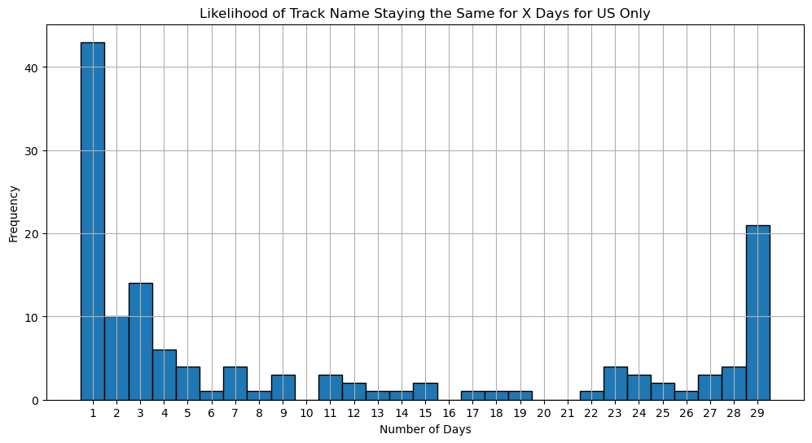

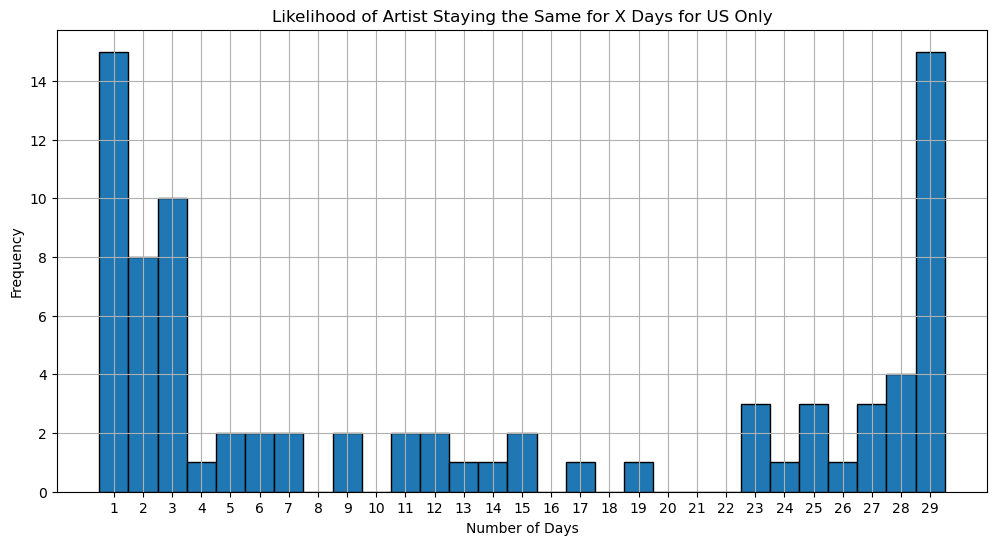

```python
# Calculate the likelihood of Track Name staying the same for x number of days
track_likelihood = Top_50_US_Merged_Data.groupby('Track Name')['ISO_Date'].nunique()

# Plot for Track Name
plt.figure(figsize=(12, 6))
plt.hist(track_likelihood, bins=range(1, track_likelihood.max() + 2), align='left', edgecolor='black')
plt.title('Likelihood of Track Name Staying the Same for X Days for US Only')
plt.xlabel('Number of Days')
plt.ylabel('Frequency')
plt.xticks(range(1, track_likelihood.max() + 1))
plt.grid()
plt.show()

# Calculate the likelihood of Artist staying the same for x number of days
artist_likelihood = Top_50_US_Merged_Data.groupby('Artists')['ISO_Date'].nunique()

# Plot for Artist
plt.figure(figsize=(12, 6))
plt.hist(artist_likelihood, bins=range(1, artist_likelihood.max() + 2), align='left', edgecolor='black')
plt.title('Likelihood of Artist Staying the Same for X Days for US Only')
plt.xlabel('Number of Days')
plt.ylabel('Frequency')
plt.xticks(range(1, artist_likelihood.max() + 1))
plt.grid()
plt.show()
```

# Summary of the Results:

1. Likelihood of Track Name Staying the Same for X Days:
- High Turnover for 1 Day: A significant number of tracks appear on the chart for only 1 day, indicating high turnover in the rankings.
- Consistency Peaks at 29 Days: A noticeable cluster of tracks remain consistent in the rankings for the entire observation period (29 days), suggesting a few tracks dominate the charts for a long time.
- Moderate Variability: The distribution between 2 and 28 days shows moderate variability, with fewer tracks staying consistent compared to 1 or 29 days.
2. Likelihood of Artist Staying the Same for X Days:
- High Turnover for 1 Day: Similar to track names, many artists appear for only 1 day.
- Peak at 29 Days: A significant number of artists also remain consistent in the rankings for 29 days, showing dominance by certain artists.
- Broader Distribution: Compared to track names, artists have a slightly broader distribution of consistency across different days, indicating that artists may have multiple tracks in the rankings or return with new entries.

# Key Insights:

- Dominance by Few Tracks and Artists: The peaks at 29 days for both tracks and artists highlight that certain tracks and artists have strong and lasting appeal.
- Frequent Turnover: A large number of 1-day entries suggest significant competition and short-lived popularity for many tracks and artists.
- Artist Loyalty vs. Track Loyalty: Artists tend to have a broader range of consistent appearances compared to individual tracks, likely due to multiple tracks being charted during the period.

These trends could provide insights into listener preferences, the competitive nature of the music charts, and the factors driving short-lived versus long-term success.

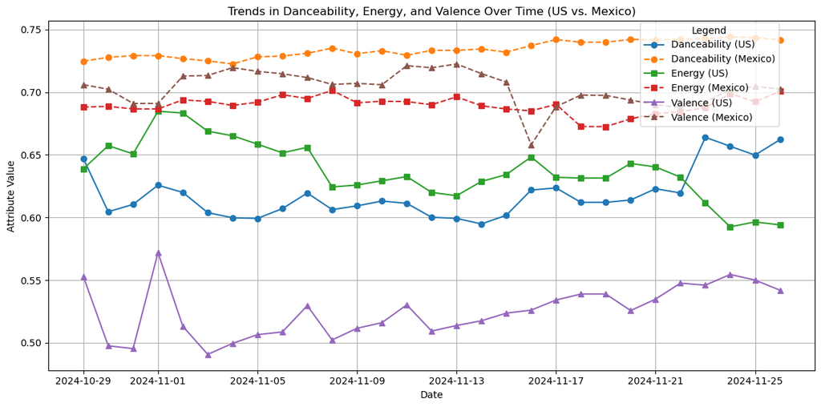

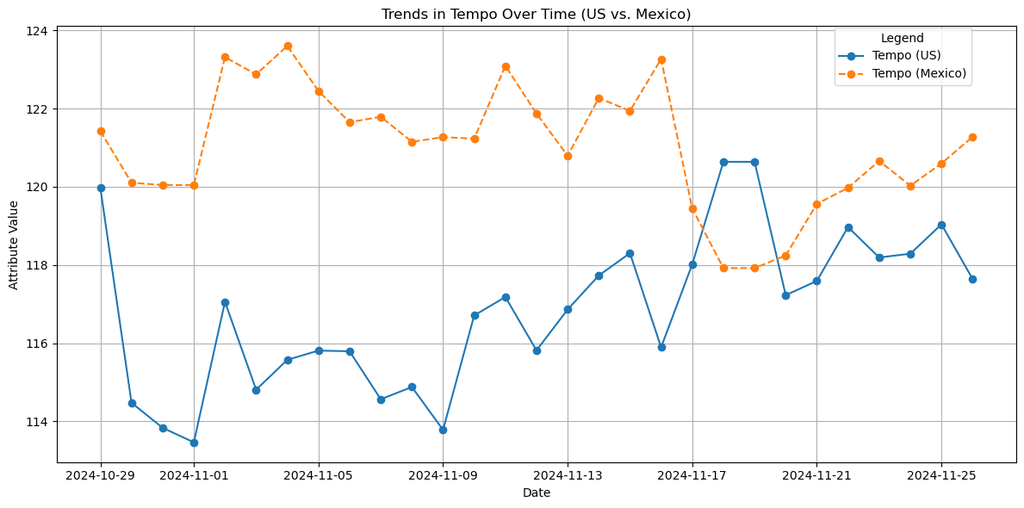

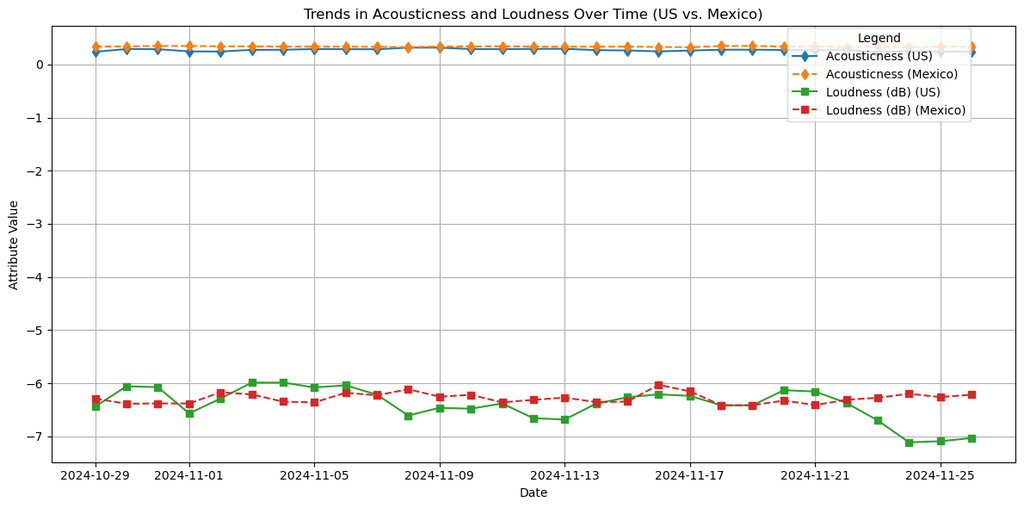

```python
# Convert ISO_Date to datetime for both datasets
Top_50_US_Merged_Data['ISO_Date'] = pd.to_datetime(Top_50_US_Merged_Data['ISO_Date'])
Top_50_Mexico_Merged_Data['ISO_Date'] = pd.to_datetime(Top_50_Mexico_Merged_Data['ISO_Date'])

# Group by date and calculate mean values for numerical attributes
numeric_columns_us = Top_50_US_Merged_Data.select_dtypes(include=['number']).columns
numeric_columns_mexico = Top_50_Mexico_Merged_Data.select_dtypes(include=['number']).columns

grouped_data_us = Top_50_US_Merged_Data.groupby('ISO_Date')[numeric_columns_us].mean()
grouped_data_mexico = Top_50_Mexico_Merged_Data.groupby('ISO_Date')[numeric_columns_mexico].mean()

# Plot Danceability, Energy, and Valence (US vs. Mexico)
fig, ax = plt.subplots(figsize=(12, 6))
ax.plot(grouped_data_us.index, grouped_data_us['Danceability'], marker='o', label='Danceability (US)', linestyle='-')
ax.plot(grouped_data_mexico.index, grouped_data_mexico['Danceability'], marker='o', label='Danceability (Mexico)', linestyle='--')
ax.plot(grouped_data_us.index, grouped_data_us['Energy'], marker='s', label='Energy (US)', linestyle='-')
ax.plot(grouped_data_mexico.index, grouped_data_mexico['Energy'], marker='s', label='Energy (Mexico)', linestyle='--')
ax.plot(grouped_data_us.index, grouped_data_us['Valence'], marker='^', label='Valence (US)', linestyle='-')
ax.plot(grouped_data_mexico.index, grouped_data_mexico['Valence'], marker='^', label='Valence (Mexico)', linestyle='--')
ax.set_title('Trends in Danceability, Energy, and Valence Over Time (US vs. Mexico)')
ax.set_xlabel('Date')
ax.set_ylabel('Attribute Value')
ax.grid()
fig.legend(
    loc='upper right', bbox_to_anchor=(0.95, 0.95), title="Legend"
)
plt.tight_layout()
plt.show()

# Plot Tempo (US vs. Mexico)
fig, ax = plt.subplots(figsize=(12, 6))
ax.plot(grouped_data_us.index, grouped_data_us['Tempo'], marker='o', label='Tempo (US)', linestyle='-')
ax.plot(grouped_data_mexico.index, grouped_data_mexico['Tempo'], marker='o', label='Tempo (Mexico)', linestyle='--')
ax.set_title('Trends in Tempo Over Time (US vs. Mexico)')
ax.set_xlabel('Date')
ax.set_ylabel('Attribute Value')
ax.grid()
fig.legend(
    loc='upper right', bbox_to_anchor=(0.95, 0.95), title="Legend"
)
plt.tight_layout()
plt.show()

# Plot Acousticness and Loudness (US vs. Mexico)
fig, ax = plt.subplots(figsize=(12, 6))
ax.plot(grouped_data_us.index, grouped_data_us['Acousticness'], marker='d', label='Acousticness (US)', linestyle='-')
ax.plot(grouped_data_mexico.index, grouped_data_mexico['Acousticness'], marker='d', label='Acousticness (Mexico)', linestyle='--')
ax.plot(grouped_data_us.index, grouped_data_us['Loudness (dB)'], marker='s', label='Loudness (dB) (US)', linestyle='-')
ax.plot(grouped_data_mexico.index, grouped_data_mexico['Loudness (dB)'], marker='s', label='Loudness (dB) (Mexico)', linestyle='--')
ax.set_title('Trends in Acousticness and Loudness Over Time (US vs. Mexico)')
ax.set_xlabel('Date')
ax.set_ylabel('Attribute Value')
ax.grid()
fig.legend(
    loc='upper right', bbox_to_anchor=(0.95, 0.95), title="Legend"
)
plt.tight_layout()
plt.show()
```

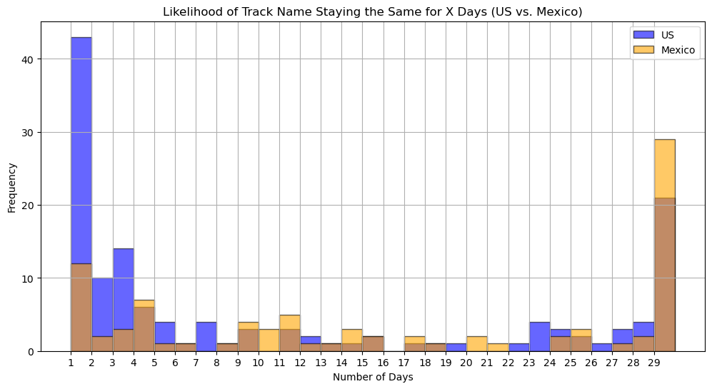

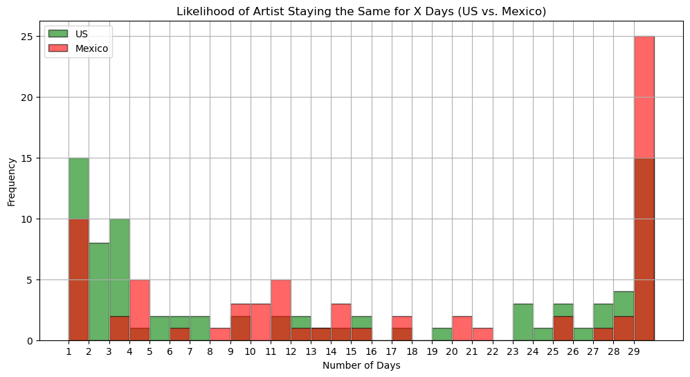

```python
# Calculate the likelihood of Track Name staying the same for x number of days for US and Mexico
track_likelihood_us = Top_50_US_Merged_Data.groupby('Track Name')['ISO_Date'].nunique()
track_likelihood_mexico = Top_50_Mexico_Merged_Data.groupby('Track Name')['ISO_Date'].nunique()

# Plot for Track Name (US vs. Mexico)
plt.figure(figsize=(12, 6))
plt.hist(track_likelihood_us, bins=range(1, track_likelihood_us.max() + 2), alpha=0.6, label='US', color='blue', edgecolor='black')
plt.hist(track_likelihood_mexico, bins=range(1, track_likelihood_mexico.max() + 2), alpha=0.6, label='Mexico', color='orange', edgecolor='black')
plt.title('Likelihood of Track Name Staying the Same for X Days (US vs. Mexico)')
plt.xlabel('Number of Days')
plt.ylabel('Frequency')
plt.xticks(range(1, max(track_likelihood_us.max(), track_likelihood_mexico.max()) + 1))
plt.legend()
plt.grid()
plt.show()

# Calculate the likelihood of Artist staying the same for x number of days for US and Mexico
artist_likelihood_us = Top_50_US_Merged_Data.groupby('Artists')['ISO_Date'].nunique()
artist_likelihood_mexico = Top_50_Mexico_Merged_Data.groupby('Artists')['ISO_Date'].nunique()

# Plot for Artist (US vs. Mexico)
plt.figure(figsize=(12, 6))
plt.hist(artist_likelihood_us, bins=range(1, artist_likelihood_us.max() + 2), alpha=0.6, label='US', color='green', edgecolor='black')
plt.hist(artist_likelihood_mexico, bins=range(1, artist_likelihood_mexico.max() + 2), alpha=0.6, label='Mexico', color='red', edgecolor='black')
plt.title('Likelihood of Artist Staying the Same for X Days (US vs. Mexico)')
plt.xlabel('Number of Days')
plt.ylabel('Frequency')
plt.xticks(range(1, max(artist_likelihood_us.max(), artist_likelihood_mexico.max()) + 1))
plt.legend()
plt.grid()
plt.show()
```

# Now let's start with the predictive modeling :)

```python
# Importing libraries
from sklearn.linear_model import LinearRegression
from sklearn.model_selection import train_test_split
from sklearn.metrics import mean_squared_error, root_mean_squared_error
from sklearn.preprocessing import PolynomialFeatures
from sklearn.pipeline import make_pipeline
from sklearn.linear_model import LogisticRegression
from sklearn.metrics import classification_report, confusion_matrix
from plotnine import *
import plotnine as p9  # For visualizations similar to ggplot
import numpy as np
import matplotlib.pyplot as plt
from sklearn.metrics import ConfusionMatrixDisplay, classification_report
```

```python
# Split into 75% training and 25% validation sets, ensuring randomness
Top_50_US_Merged_Training_Data, Top_50_US_Merged_Val_Data = train_test_split(
    Top_50_US_Merged_Data,
    test_size=0.25,
    random_state=42  # Ensures reproducibility
)

# Save the splits to new CSV files
Top_50_US_Merged_Training_Data.to_csv('Top_50_US_Merged_Training_Data.csv', index=False)
Top_50_US_Merged_Val_Data.to_csv('Top_50_US_Merged_Val_Data.csv', index=False)

# Output confirmation
print("Training and validation datasets saved as 'Top_50_US_Merged_Training_Data.csv' and 'Top_50_US_Merged_Val_Data.csv'.")

# Print the number of rows in each split
Train_Row_Count = Top_50_US_Merged_Training_Data.shape[0]
Val_Row_Count = Top_50_US_Merged_Val_Data.shape[0]

print(Train_Row_Count, "rows in training dataset")
print(Val_Row_Count, "rows in validation dataset")
```

```
Training and validation datasets saved as 'Top_50_US_Merged_Training_Data.csv' and 'Top_50_US_Merged_Val_Data.csv'.
1087 rows in training dataset
363 rows in validation dataset
```

# Business Case

Build a predictive model using the Top 50 songs’ characteristics to estimate the features required for a song to chart in the Top 50. Validate the model using a separate dataset of Top 50 songs and evaluate its performance. Additionally, provide insights into the key features influencing a song’s likelihood to be in the Top 50 and summarize the range of these features.

```python
# # Explore the dataset ----------------------------------------------------------------
# print(Top_50_US_Merged_Training_Data.info())
# print(Top_50_US_Merged_Training_Data.describe())

# # Identify unique values in important columns
# print("Unique values in 'Artists':", Top_50_US_Merged_Training_Data['Artists'].nunique())
# print("Unique values in 'Track Name':", Top_50_US_Merged_Training_Data['Track Name'].nunique())
```

```python
# Add a binary column 'in_top_50' to label all songs as being in the Top 50
Top_50_US_Merged_Training_Data['in_top_50'] = 1
Top_50_US_Merged_Val_Data['in_top_50'] = 1

# Define the features to be used for the logistic regression model
features = ['Danceability', 'Energy', 'Tempo', 'Valence', 'Acousticness', 'Liveness', 'Loudness (dB)']

# Extract X (features) and y (target) for training and validation datasets
X_train = Top_50_US_Merged_Training_Data[features]
y_train = Top_50_US_Merged_Training_Data['in_top_50']

X_val = Top_50_US_Merged_Val_Data[features]
y_val = Top_50_US_Merged_Val_Data['in_top_50']

# Print the shape of the training and validation datasets for verification
print(f"Training Features Shape: {X_train.shape}, Training Target Shape: {y_train.shape}")
print(f"Validation Features Shape: {X_val.shape}, Validation Target Shape: {y_val.shape}")

# Define realistic ranges for features to generate synthetic non-Top 50 data
realistic_ranges = {
    'Danceability': (0.3, 0.7),
    'Energy': (0.2, 0.6),
    'Tempo': (70, 120),
    'Valence': (0.2, 0.6),
    'Acousticness': (0.5, 1.0),
    'Liveness': (0.1, 0.4),
    'Loudness (dB)': (-30, -10)
}

# Generate synthetic non-Top 50 songs for training data
num_synthetic_train_samples = len(Top_50_US_Merged_Training_Data)
synthetic_train_samples = pd.DataFrame({
    feature: np.random.uniform(
        low=realistic_ranges[feature][0],
        high=realistic_ranges[feature][1],
        size=num_synthetic_train_samples
    )
    for feature in realistic_ranges.keys()
})

# Label synthetic training samples as not in Top 50
synthetic_train_samples['in_top_50'] = 0

# Combine Top 50 training songs with synthetic non-Top 50 songs to create a balanced training dataset
balanced_train_data = pd.concat([Top_50_US_Merged_Training_Data, synthetic_train_samples], ignore_index=True)

# Separate features and target for the balanced training dataset
X_train = balanced_train_data[features]
y_train = balanced_train_data['in_top_50']

# Train a logistic regression model on the balanced training dataset
model = LogisticRegression(max_iter=1000, random_state=42)
model.fit(X_train, y_train)

# Generate synthetic non-Top 50 songs for validation data
num_synthetic_val_samples = len(Top_50_US_Merged_Val_Data)
synthetic_val_samples = pd.DataFrame({
    feature: np.random.uniform(
        low=realistic_ranges[feature][0],
        high=realistic_ranges[feature][1],
        size=num_synthetic_val_samples
    )
    for feature in realistic_ranges.keys()
})

# Label synthetic validation samples as not in Top 50
synthetic_val_samples['in_top_50'] = 0

# Combine Top 50 validation songs with synthetic non-Top 50 songs
balanced_val_data = pd.concat([Top_50_US_Merged_Val_Data, synthetic_val_samples], ignore_index=True)

# Separate features and target for the balanced validation dataset
X_balanced_val = balanced_val_data[features]
y_balanced_val = balanced_val_data['in_top_50']

# Predict on the balanced validation set using the trained model
y_pred_balanced = model.predict(X_balanced_val)

# Evaluate the model's performance on the balanced validation set
print("\nClassification Report on Balanced Validation Set:")
print(classification_report(y_balanced_val, y_pred_balanced))

print("\nConfusion Matrix on Balanced Validation Set:")
print(confusion_matrix(y_balanced_val, y_pred_balanced))
```

```
Training Features Shape: (1087, 7), Training Target Shape: (1087,)
Validation Features Shape: (363, 7), Validation Target Shape: (363,)

Classification Report on Balanced Validation Set:
              precision    recall  f1-score   support

           0       0.99      0.96      0.98       363
           1       0.97      0.99      0.98       363

    accuracy                           0.98       726
   macro avg       0.98      0.98      0.98       726
weighted avg       0.98      0.98      0.98       726


Confusion Matrix on Balanced Validation Set:
[[350  13]
 [  2 361]]
```

# Spotify has deprecated some of their functionality and thus we are unable to pull non-top 50 data. This is document at the websites below:

- https://community.spotify.com/t5/Spotify-for-Developers/Intermittent-404s-Getting-Playlist-Tracks-via-API/td-p/5356770
- https://developer.spotify.com/blog/2024-11-27-changes-to-the-web-api

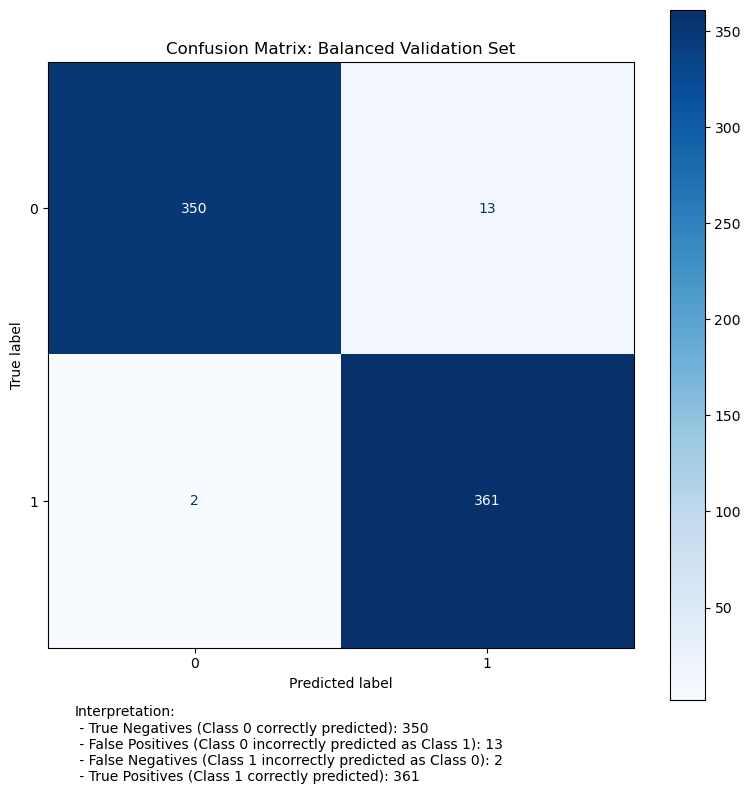

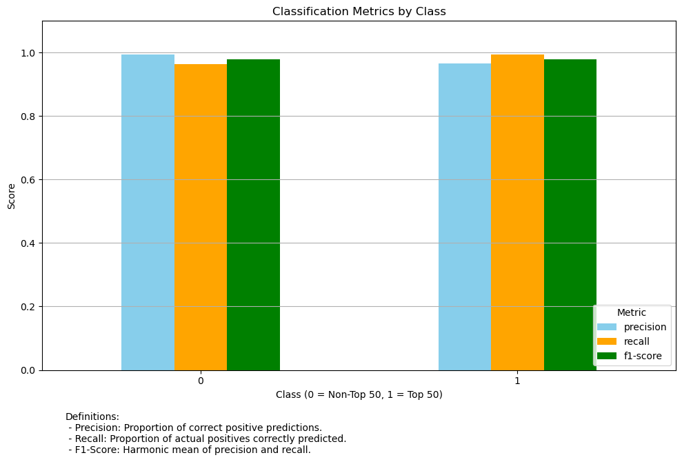

```python
import matplotlib.pyplot as plt
from sklearn.metrics import ConfusionMatrixDisplay, classification_report
import pandas as pd

# Evaluate the model's performance on the balanced validation set
overall_accuracy = model.score(X_balanced_val, y_balanced_val)
classification_metrics = classification_report(y_balanced_val, y_pred_balanced, output_dict=True)

# Confusion matrix as a DataFrame
conf_matrix = pd.crosstab(y_balanced_val, y_pred_balanced, rownames=['Actual'], colnames=['Predicted'])

# Confusion matrix visualization with interpretation embedded
fig, ax = plt.subplots(figsize=(8, 8))
disp = ConfusionMatrixDisplay.from_predictions(
    y_balanced_val, y_pred_balanced, ax=ax, cmap='Blues'
)
plt.title("Confusion Matrix: Balanced Validation Set")
plt.grid(False)

# Add interpretation as text slightly below the confusion matrix
interpretation = (
    f"Interpretation:\n"
    f" - True Negatives (Class 0 correctly predicted): {conf_matrix.loc[0, 0]}\n"
    f" - False Positives (Class 0 incorrectly predicted as Class 1): {conf_matrix.loc[0, 1]}\n"
    f" - False Negatives (Class 1 incorrectly predicted as Class 0): {conf_matrix.loc[1, 0]}\n"
    f" - True Positives (Class 1 correctly predicted): {conf_matrix.loc[1, 1]}"
)
plt.gcf().text(0.1, 0.02, interpretation, fontsize=10, wrap=True, horizontalalignment='left')
plt.tight_layout(rect=[0, 0.1, 1, 1])  # Adjust layout to provide space for interpretation text
plt.show()

# Convert classification report to DataFrame for plotting
df_report = pd.DataFrame(classification_metrics).transpose()

# Plot Precision, Recall, F1-Score for each class
fig, ax = plt.subplots(figsize=(10, 6))
df_report.loc[['0', '1'], ['precision', 'recall', 'f1-score']].plot.bar(
    ax=ax, rot=0, color=['skyblue', 'orange', 'green']
)
plt.title("Classification Metrics by Class")
plt.ylabel("Score")
plt.xlabel("Class (0 = Non-Top 50, 1 = Top 50)")
plt.ylim(0, 1.1)
plt.legend(loc="lower right", title="Metric")
plt.grid(axis='y')

# Add definitions of metrics below the chart
definitions = (
    "Definitions:\n"
    " - Precision: Proportion of correct positive predictions.\n"
    " - Recall: Proportion of actual positives correctly predicted.\n"
    " - F1-Score: Harmonic mean of precision and recall."
)
plt.figtext(0.1, -0.1, definitions, wrap=True, horizontalalignment='left', fontsize=10)
plt.tight_layout()
plt.show()
```